# Coursework Report

*N* removed NAs: 4

*N* removed <18: 18

**Correct typo age:** 18

*N* total clean: 146

| Group | *N* | *M*<sub>age</sub> | % green |
| --- | --- | --- | --- |
| Control | 73 | 20.89 | 38.81 |
| Experim | 73 | 21.22 | 52.05 |

| Gender | *N* | *M*<sub>age</sub> | % green |
| --- | --- | --- | --- |
| Female | 71 | 20.89 | 49.77 |
| Male | 48 | 21.35 | 40.97 |
| Other | 27 | 20.96 | 41.98 |

**Main analysis results**

**car:**  
χ<sup>2</sup>(1) = 5.41, *p* = .020

**cleaner:**  
χ<sup>2</sup>(1) = 0.11, *p* = .738

**dishwasher:**  
χ<sup>2</sup>(1) = 2.75, *p* = .097

[interactive chart not shown]

[figure not shown]

[interactive chart not shown]

# Coursework Report

Analysing Data, Spring 2020

```
## # A tibble: 504 x 6
##    id_code gender age   condition category product
##    <fct>   <fct>  <chr> <fct>     <fct>    <fct>
##  1 KMBA    other  17    control   luxury   cleaner
##  2 KMBA    other  17    control   green    car
##  3 KMBA    other  17    control   luxury   dishwasher
##  4 VQHS    male   21    control   luxury   cleaner
##  5 VQHS    male   21    control   luxury   car
##  6 VQHS    male   21    control   luxury   dishwasher
##  7 ZRGN    female 22    control   luxury   cleaner
##  8 ZRGN    female 22    control   luxury   car
##  9 ZRGN    female 22    control   luxury   dishwasher
## 10 JGMQ    female 18    control   luxury   cleaner
## # ... with 494 more rows
```

```
## tibble [504 x 6] (S3: tbl_df/tbl/data.frame)
##  $ id_code  : Factor w/ 168 levels "ABHN","AHOR",..: 68 68 68 146 146 146 166 166 166 59 ...
##  $ gender   : Factor w/ 3 levels "female","male",..: 3 3 3 2 2 2 1 1 1 1 ...
##  $ age      : chr [1:504] "17" "17" "17" "21" ...
##  $ condition: Factor w/ 3 levels "contro","control",..: 2 2 2 2 2 2 2 2 2 2 ...
##  $ category : Factor w/ 2 levels "luxury","green": 1 2 1 1 1 1 1 1 1 1 ...
##  $ product  : Factor w/ 3 levels "cleaner","car",..: 1 2 3 1 2 3 1 2 3 1 ...
```

```
##     id_code       gender        age                   condition     category         product
##  ABHN   :  3   female:246   Length:504         contro      :  1   luxury:278   cleaner   :168
##  AHOR   :  3   male  :162   Class :character   control     :251   green :226   car       :168
##  AIRA   :  3   other : 96   Mode  :character   experimental:252                dishwasher:168
##  ANDK   :  3
##  AOAZ   :  3
##  AQHO   :  3
##  (Other):486
```

```
## .
## 12 15 16 17 18 19 1w 20 21 22 23 24 25 26 28  6  7
##  3  3 15 27 41 66  1 78 93 66 39 15 30  6  3  3  3
```

```
## # A tibble: 504 x 6
##    id_code gender   age condition category product
##    <fct>   <fct>  <dbl> <fct>     <fct>    <fct>
##  1 KMBA    other     17 control   luxury   cleaner
##  2 KMBA    other     17 control   green    car
##  3 KMBA    other     17 control   luxury   dishwasher
##  4 VQHS    male      21 control   luxury   cleaner
##  5 VQHS    male      21 control   luxury   car
##  6 VQHS    male      21 control   luxury   dishwasher
##  7 ZRGN    female    22 control   luxury   cleaner
##  8 ZRGN    female    22 control   luxury   car
##  9 ZRGN    female    22 control   luxury   dishwasher
## 10 JGMQ    female    18 control   luxury   cleaner
## # ... with 494 more rows
```

```
##     id_code       gender         age               condition     category         product
##  ABHN   :  3   female:246   Min.   : 6.00   contro      :  1   luxury:278   cleaner   :168
##  AHOR   :  3   male  :162   1st Qu.:19.00   control     :251   green :226   car       :168
##  AIRA   :  3   other : 96   Median :21.00   experimental:252                dishwasher:168
##  ANDK   :  3                Mean   :20.41
##  AOAZ   :  3                3rd Qu.:22.00
##  AQHO   :  3                Max.   :28.00
##  (Other):486                NA's   :12
```

```
## .
##  6  7 12 15 16 17 18 19 20 21 22 23 24 25 26 28
##  3  3  3  3 15 27 42 66 78 93 66 39 15 30  6  3
```

```
## # A tibble: 438 x 7
##    id_code gender   age condition category product    conition
##    <fct>   <fct>  <dbl> <fct>     <fct>    <fct>      <fct>
##  1 VQHS    male      21 control   luxury   cleaner    control
##  2 VQHS    male      21 control   luxury   car        control
##  3 VQHS    male      21 control   luxury   dishwasher control
##  4 ZRGN    female    22 control   luxury   cleaner    control
##  5 ZRGN    female    22 control   luxury   car        control
##  6 ZRGN    female    22 control   luxury   dishwasher control
##  7 JGMQ    female    18 control   luxury   cleaner    control
##  8 JGMQ    female    18 control   luxury   car        control
##  9 JGMQ    female    18 control   green    dishwasher control
## 10 KCYA    male      20 control   luxury   cleaner    control
## # ... with 428 more rows
```

```
##     id_code       gender         age               condition     category         product
##  ABHN   :  3   female:213   Min.   :18.00   control     :219   luxury:239   cleaner   :146
##  AHOR   :  3   male  :144   1st Qu.:20.00   experimental:219   green :199   car       :146
##  AIRA   :  3   other : 81   Median :21.00                                   dishwasher:146
##  ANDK   :  3                Mean   :21.05
##  AOAZ   :  3                3rd Qu.:22.00
##  AQHO   :  3                Max.   :28.00
##  (Other):420
```

# Methods

## Participants

The study was initially conducted with 168 participants however there was a removal of participants data due to the ethical obligation for the study to only include data provided by individuals over the age 18, in conjunction with this participants with segments of unavailable age data (NA) were also removed. After the tidying of the results 146 participants remained,(Mage = 21.05, SDage = 2.06, range = 18 - 28), all of which were included in the following analyses and the chi-squared test.

```
## # A tibble: 1 x 4
##   mean_age sd_age min_age max_age
##      <dbl>  <dbl>   <dbl>   <dbl>
## 1     21.0   2.06      18      28
```

```
## # A tibble: 6 x 5
## # Groups:   gender [3]
##   gender condition        n mean_age sd_age
##   <fct>  <fct>        <int>    <dbl>  <dbl>
## 1 female control        105     20.8   1.76
## 2 female experimental   108     21.0   2.08
## 3 male   control         78     20.8   2.05
## 4 male   experimental    66     22.0   2.55
## 5 other  control         36     21.2   1.86
## 6 other  experimental    45     20.7   1.71
```

| gender | condition | n | mean_age | sd_age |
| --- | --- | --- | --- | --- |
| female | control | 105 | 20.80000 | 1.761774 |
| female | experimental | 108 | 20.97222 | 2.084470 |
| male | control | 78 | 20.84615 | 2.045438 |
| male | experimental | 66 | 21.95455 | 2.550607 |
| other | control | 36 | 21.25000 | 1.857418 |
| other | experimental | 45 | 20.73333 | 1.710927 |

```
##
##          control experimental
##   luxury      47           32
##   green       26           41
```

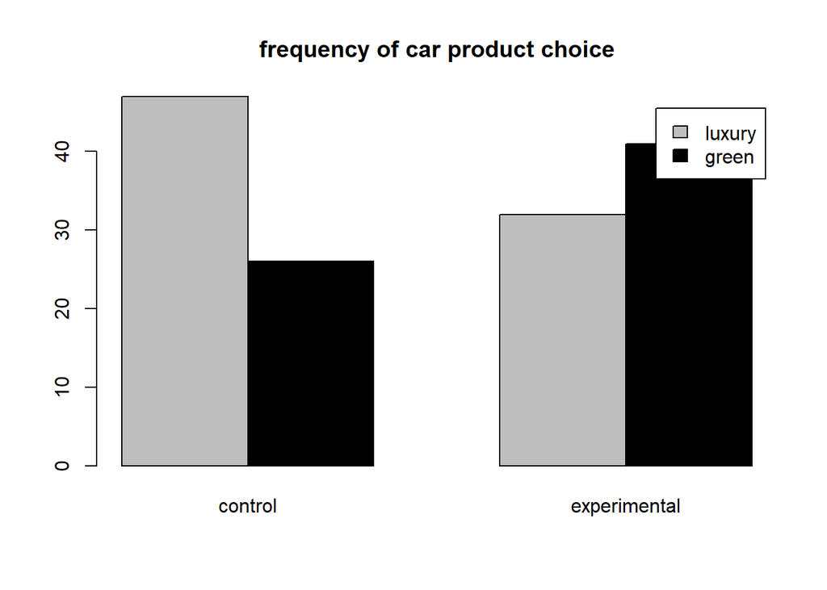

```
##
##          control experimental
##   luxury      44           33
##   green       29           40
```

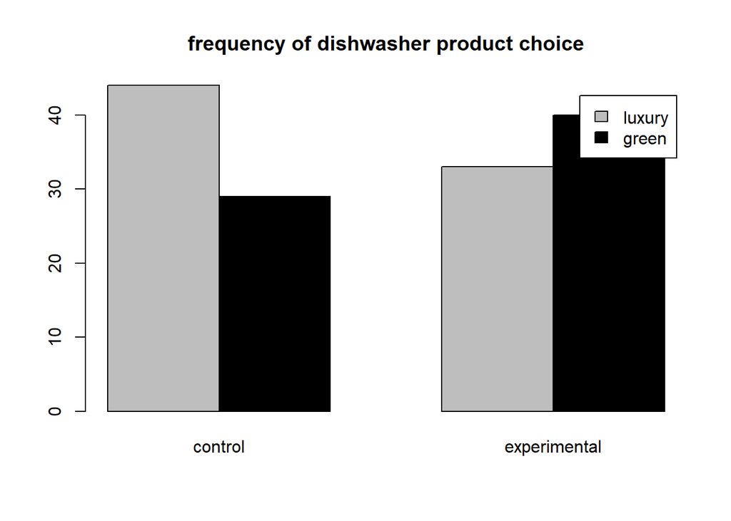

```
##
##          control experimental
##   luxury      43           40
##   green       30           33
```

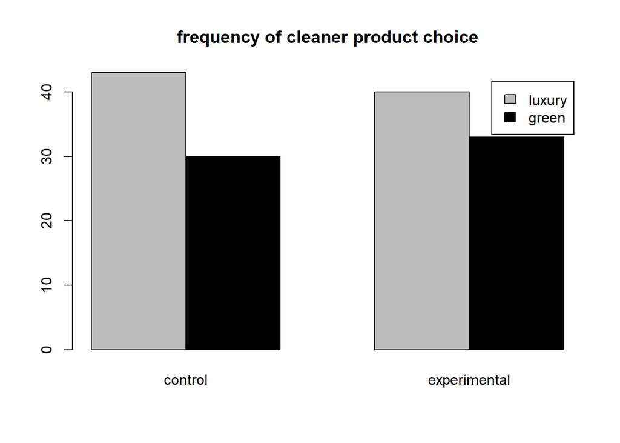

```
##
##                luxury green
##   control         134    85
##   experimental    105   114
```

```
##
##  Pearson's Chi-squared test with Yates' continuity correction
##
## data:  count
## X-squared = 7.22, df = 1, p-value = 0.007209
```

## Design

The study investigated the effects of status motives on the prosocial behaviour of purchasing green products, as a replication study of Griskevicius, Tybur & Bergh(2010) research. The generation of status motives was through priming participants in the experimental condition with a short story and comparing their results to those assigned to the control group who did not read the story. A car, dishwasher and cleaner were the three product types the experiment was conducted around each with two options either a luxury version of the item or a green version. The choice between the products measured the prosocial behaviour of the participant. The participants in the high status experimental condition will have picked more of the green products compared with those in the control. The chi-squared test will be used for the analysis of results, whether status motives predicts purchasing of green products.

# Results

# Discussion

The research is inline with ‘Going Green to Be Seen: Status, Reputation, and Conspicuous Conservation’ by Griskevicius, Tybur & Bergh(2010), as the produced results for both show the difference in green product purchase between those in the experimental status condition compared to those in the control. The car is for both studies the most drastic result between the two conditions, however the replication for the cleaner does show a different trend to the soap results of the first study. The differences suggest may be due to participant individual differences between the two studies or this could be due to the price difference as cleaner is much cheaper than a car or a dishwasher. This disparity should be investigated further looking at the difference the price of a product has on the effect status motives has on consumer behaviour. Both this replication and original study consisted of participants around university age and so future replications of this study should focus on older age brackets. The need for higher status is a primary behaviour (Anderson, Hildreth & Howland, 2015) is a cross cultural desire and with reason as it has been found to increase mating prospects for men (Sundie et al, 2011). The significance around the world garners support for how it can affect consumer behaviour in such a way as seen in this study, suggesting the real life applications eliciting status motives in ad’s for green products could have. On the other hand the design of this study in a lab situation, is a limitation and in order to more distinctively test the real world application of status motives, further research should incorporate practical applications of choosing green products. One such study ‘Consumer attitude and purchase intention toward green energy brands: The roles of psychological benefits and environmental concern’ (Hartmann & Apaolaza-Ibáñez, 2012) found that suggesting ‘psychological brand benefits’ in ads for green electricity elicited more interest from consumers. These findings display the real world effect that emphasising a products ability to improves ones image can have, but research specifically concerning status motives would need to be conducted to fully determine their real world application in ads. This study supports the original study it was replicated from, demonstrating the ability status motives has in driving prosocial behaviour specifically pro-environmental green consumer behaviour. Research that can help inform the marketing of green products to increase sales.

# References

Anderson, C., Hildreth, J. A. D., & Howland, L. (2015). Is the desire for status a fundamental human motive? A review of the empirical literature. Psychological Bulletin, 141(3), 574–601.

Griskevicius, V., Tybur, J., & Bergh, B. V. D. (2010). Going Green to Be Seen: Status, Reputation, and Conspicuous Conservation. PsycEXTRA Dataset.

Hartmann, P., & Apaolaza-Ibáñez, V. (2012). Consumer attitude and purchase intention toward green energy brands: The roles of psychological benefits and environmental concern. Journal of Business Research, 65(9), 1254–1263.

Sundie, J. M., Kenrick, D. T., Griskevicius, V., Tybur, J. M., Vohs, K. D., & Beal, D. J. (2011). Peacocks, Porsches, and Thorstein Veblen: Conspicuous consumption as a sexual signaling system. Journal of Personality and Social Psychology, 100(4), 664–680.